[figure not shown]

```python
import pandas as pd
import seaborn as sns
import matplotlib.pyplot as plt
import numpy as np
import geopandas as gpd
from shapely.geometry import Point
from datetime import datetime, date
import warnings
warnings.filterwarnings('ignore')
pd.set_option('display.max_column', 80)
```

# Contexte

Vous travaillez pour la ville de Seattle. Pour atteindre son objectif de ville neutre en émissions de carbone en 2050, votre équipe s’intéresse de près à la consommation et aux émissions des bâtiments non destinés à l’habitation. Des relevés minutieux ont été effectués par les agents de la ville en 2016. Voici les données et leur source. Cependant, ces relevés sont coûteux à obtenir, et à partir de ceux déjà réalisés, vous voulez tenter de prédire les émissions de CO2 et la consommation totale d’énergie de bâtiments non destinés à l’habitation pour lesquels elles n’ont pas encore été mesurées.

# Objectifs

Vous cherchez également à évaluer l’intérêt de l’**ENERGY STAR Score** pour la prédiction d’émissions, qui est fastidieux à calculer avec l’approche utilisée actuellement par votre équipe. Vous l'intégrerez dans la modélisation et jugerez de son intérêt.

```python
df = pd.read_csv('Building_Benchmarking.csv')
```

```python
df_log = pd.read_csv('Building_Log_Benchmarking.csv')
```

Head() pour afficher les 5 premières lignes du dataframe `df`.

```python
df.head()
```

|  | OSEBuildingID | DataYear | BuildingType | PrimaryPropertyType | PropertyName | Latitude | Longitude | YearBuilt | NumberofBuildings | NumberofFloors | PropertyGFATotal | PropertyGFAParking | PropertyGFABuilding(s) | ListOfAllPropertyUseTypes | LargestPropertyUseType | SecondLargestPropertyUseType | ThirdLargestPropertyUseType | ENERGYSTARScore | SiteEUI(kBtu/sf) | SourceEUI(kBtu/sf) | SiteEnergyUse(kBtu) | SteamUse(kBtu) | Electricity(kBtu) | NaturalGas(kBtu) | TotalGHGEmissions | pourcentage_LargestPropertyUseTypeGFA | pourcentage_SecondLargestPropertyUseTypeGFA | pourcentage_ThirdLargestPropertyUseTypeGFA |
| --- | --- | --- | --- | --- | --- | --- | --- | --- | --- | --- | --- | --- | --- | --- | --- | --- | --- | --- | --- | --- | --- | --- | --- | --- | --- | --- | --- | --- |
| 0 | 1 | 2015 | NonResidential | Hotel | MAYFLOWER PARK HOTEL | 47.612190 | -122.337997 | 1927 | 1.0 | 12.0 | 88434 | 0.0 | 88434.0 | Hotel | Hotel | NaN | NaN | 65.0 | 78.9 | 173.5 | 6981428.0 | 2023032.0 | 3686160.0 | 1272388.0 | 249.43 | 100.00 | 0.00 | 0.00 |
| 1 | 2 | 2015 | NonResidential | Hotel | PARAMOUNT HOTEL | 47.613106 | -122.333358 | 1996 | 1.0 | 11.0 | 103566 | 15064.0 | 88502.0 | Hotel, Parking, Restaurant | Hotel | Parking | Restaurant | 51.0 | 94.4 | 191.3 | 8354235.0 | 0.0 | 3905411.0 | 4448985.0 | 263.51 | 80.99 | 14.55 | 4.46 |
| 2 | 3 | 2015 | NonResidential | Hotel | WESTIN HOTEL | 47.613349 | -122.337699 | 1969 | 1.0 | 41.0 | 961990 | 0.0 | 961990.0 | Hotel, Parking, Swimming Pool | Hotel | Parking | Swimming Pool | 18.0 | 96.6 | 242.7 | 73130656.0 | 19660404.0 | 49762435.0 | 3709900.0 | 2061.48 | 78.72 | 10.40 | 0.00 |
| 3 | 5 | 2015 | NonResidential | Hotel | HOTEL MAX | 47.614216 | -122.336609 | 1926 | 1.0 | 10.0 | 61320 | 0.0 | 61320.0 | Hotel | Hotel | NaN | NaN | 1.0 | 460.4 | 636.3 | 28229320.0 | 23458518.0 | 2769023.0 | 2001894.0 | 1936.34 | 100.00 | 0.00 | 0.00 |
| 4 | 9 | 2015 | Nonresidential COS | Other | WEST PRECINCT (SEATTLE POLICE) | 47.616439 | -122.336764 | 1999 | 1.0 | 2.0 | 97288 | 37198.0 | 60090.0 | Police Station | Police Station | NaN | NaN | NaN | 135.7 | 313.5 | 12051984.0 | 0.0 | 7271004.0 | 4781283.0 | 304.62 | 91.31 | 0.00 | 0.00 |

la taille du dataframe avec shape

```python
df.shape
```

```
(2674, 28)
```

min, max, moyenne, écart type, etc) pour toutes les variables quantitatives avec describes

```python
df.describe()
```

|  | OSEBuildingID | DataYear | Latitude | Longitude | YearBuilt | NumberofBuildings | NumberofFloors | PropertyGFATotal | PropertyGFAParking | PropertyGFABuilding(s) | ENERGYSTARScore | SiteEUI(kBtu/sf) | SourceEUI(kBtu/sf) | SiteEnergyUse(kBtu) | SteamUse(kBtu) | Electricity(kBtu) | NaturalGas(kBtu) | TotalGHGEmissions | pourcentage_LargestPropertyUseTypeGFA | pourcentage_SecondLargestPropertyUseTypeGFA | pourcentage_ThirdLargestPropertyUseTypeGFA |
| --- | --- | --- | --- | --- | --- | --- | --- | --- | --- | --- | --- | --- | --- | --- | --- | --- | --- | --- | --- | --- | --- |
| count | 2674.000000 | 2674.000000 | 2674.000000 | 2674.000000 | 2674.000000 | 2674.000000 | 2674.000000 | 2.674000e+03 | 2674.000000 | 2.674000e+03 | 1786.000000 | 2674.000000 | 2674.000000 | 2.674000e+03 | 2.674000e+03 | 2.674000e+03 | 2.674000e+03 | 2674.000000 | 2674.000000 | 2674.000000 | 2674.000000 |
| mean | 15453.525804 | 2015.512341 | 47.614603 | -122.333696 | 1960.838818 | 1.114435 | 4.254675 | 1.184212e+05 | 14939.116679 | 1.034821e+05 | 64.709966 | 71.807530 | 178.210135 | 7.785679e+06 | 4.035296e+05 | 5.683280e+06 | 1.658018e+06 | 158.824570 | 82.248280 | 13.386945 | 2.135636 |
| std | 13154.516387 | 0.499941 | 0.046718 | 0.024022 | 32.955544 | 2.375913 | 6.492263 | 2.682347e+05 | 46765.031227 | 2.497738e+05 | 28.472265 | 74.093515 | 188.132233 | 2.454841e+07 | 4.330989e+06 | 1.816080e+07 | 5.853002e+06 | 549.857837 | 20.126535 | 21.167726 | 6.351193 |
| min | 1.000000 | 2015.000000 | 47.499170 | -122.411820 | 1900.000000 | 1.000000 | 0.000000 | 1.128500e+04 | 0.000000 | 1.092500e+04 | 1.000000 | 0.200000 | 0.000000 | 1.144100e+04 | 0.000000e+00 | 0.000000e+00 | 0.000000e+00 | 0.080000 | 18.350000 | 0.000000 | 0.000000 |
| 25% | 572.000000 | 2015.000000 | 47.585030 | -122.343201 | 1929.000000 | 1.000000 | 1.000000 | 2.901975e+04 | 0.000000 | 2.812600e+04 | 48.000000 | 33.100000 | 77.400000 | 1.180530e+06 | 0.000000e+00 | 7.005642e+05 | 0.000000e+00 | 19.202500 | 66.235000 | 0.000000 | 0.000000 |
| 50% | 20986.000000 | 2016.000000 | 47.611655 | -122.333354 | 1965.000000 | 1.000000 | 2.000000 | 4.881950e+04 | 0.000000 | 4.664500e+04 | 72.000000 | 51.750000 | 132.600002 | 2.456574e+06 | 0.000000e+00 | 1.596202e+06 | 4.220580e+05 | 47.150000 | 90.860000 | 1.950000 | 0.000000 |
| 75% | 24374.000000 | 2016.000000 | 47.645885 | -122.322899 | 1988.000000 | 1.000000 | 4.000000 | 1.068600e+05 | 0.000000 | 9.530650e+04 | 88.000000 | 81.400001 | 205.200001 | 6.785792e+06 | 0.000000e+00 | 4.855296e+06 | 1.329851e+06 | 133.670000 | 100.000000 | 24.932500 | 0.000000 |
| max | 50226.000000 | 2016.000000 | 47.733870 | -122.258640 | 2015.000000 | 111.000000 | 76.000000 | 9.320156e+06 | 512608.000000 | 9.320156e+06 | 100.000000 | 834.400024 | 2620.000000 | 8.739237e+08 | 1.349435e+08 | 6.570744e+08 | 1.381912e+08 | 12307.160000 | 100.000000 | 630.150000 | 150.940000 |

```python
df.columns
```

```
Index(['OSEBuildingID', 'DataYear', 'BuildingType', 'PrimaryPropertyType',
       'PropertyName', 'Latitude', 'Longitude', 'YearBuilt',
       'NumberofBuildings', 'NumberofFloors', 'PropertyGFATotal',
       'PropertyGFAParking', 'PropertyGFABuilding(s)',
       'ListOfAllPropertyUseTypes', 'LargestPropertyUseType',
       'SecondLargestPropertyUseType', 'ThirdLargestPropertyUseType',
       'ENERGYSTARScore', 'SiteEUI(kBtu/sf)', 'SourceEUI(kBtu/sf)',
       'SiteEnergyUse(kBtu)', 'SteamUse(kBtu)', 'Electricity(kBtu)',
       'NaturalGas(kBtu)', 'TotalGHGEmissions',
       'pourcentage_LargestPropertyUseTypeGFA',
       'pourcentage_SecondLargestPropertyUseTypeGFA',
       'pourcentage_ThirdLargestPropertyUseTypeGFA'],
      dtype='object')
```

```python
for col in df.columns:
    print(f'{col :-<70} {df[col].nunique()}')
```

```
OSEBuildingID--------------------------------------------------------- 1409
DataYear-------------------------------------------------------------- 2
BuildingType---------------------------------------------------------- 4
PrimaryPropertyType--------------------------------------------------- 25
PropertyName---------------------------------------------------------- 2578
Latitude-------------------------------------------------------------- 2510
Longitude------------------------------------------------------------- 2430
YearBuilt------------------------------------------------------------- 113
NumberofBuildings----------------------------------------------------- 14
NumberofFloors-------------------------------------------------------- 43
PropertyGFATotal------------------------------------------------------ 1385
PropertyGFAParking---------------------------------------------------- 319
PropertyGFABuilding(s)------------------------------------------------ 1398
ListOfAllPropertyUseTypes--------------------------------------------- 325
LargestPropertyUseType------------------------------------------------ 51
SecondLargestPropertyUseType------------------------------------------ 45
ThirdLargestPropertyUseType------------------------------------------- 38
ENERGYSTARScore------------------------------------------------------- 100
SiteEUI(kBtu/sf)------------------------------------------------------ 1615
SourceEUI(kBtu/sf)---------------------------------------------------- 2110
SiteEnergyUse(kBtu)--------------------------------------------------- 2669
SteamUse(kBtu)-------------------------------------------------------- 195
Electricity(kBtu)----------------------------------------------------- 2671
NaturalGas(kBtu)------------------------------------------------------ 1894
TotalGHGEmissions----------------------------------------------------- 2477
pourcentage_LargestPropertyUseTypeGFA--------------------------------- 886
pourcentage_SecondLargestPropertyUseTypeGFA--------------------------- 703
pourcentage_ThirdLargestPropertyUseTypeGFA---------------------------- 297
```

```python
#info()
df.info()
```

```
<class 'pandas.core.frame.DataFrame'>
RangeIndex: 2674 entries, 0 to 2673
Data columns (total 28 columns):
 #   Column                                       Non-Null Count  Dtype
---  ------                                       --------------  -----
 0   OSEBuildingID                                2674 non-null   int64
 1   DataYear                                     2674 non-null   int64
 2   BuildingType                                 2674 non-null   object
 3   PrimaryPropertyType                          2674 non-null   object
 4   PropertyName                                 2674 non-null   object
 5   Latitude                                     2674 non-null   float64
 6   Longitude                                    2674 non-null   float64
 7   YearBuilt                                    2674 non-null   int64
 8   NumberofBuildings                            2674 non-null   float64
 9   NumberofFloors                               2674 non-null   float64
```

[output cut: 20 more lines]

# Feature Engineering

## Build Age

```python
df['Build_Age'] = df['DataYear'] - df['YearBuilt']
```

```python
df['Build_Age'].max()
```

```
116
```

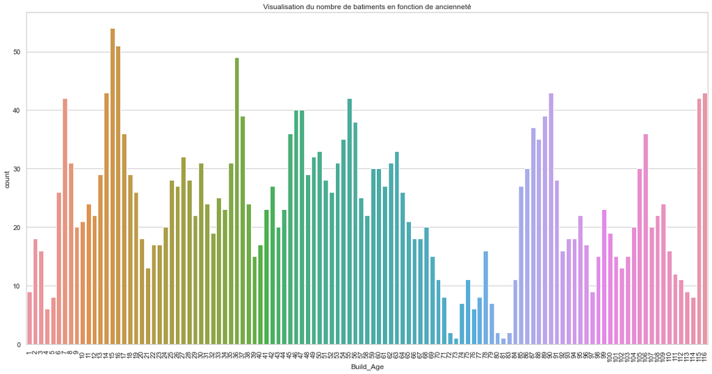

```python
plt.figure(figsize=(20,10))
sns.set(font_scale=1)
sns.set_style('whitegrid')
sns.countplot(x='Build_Age', data=df).set(title='Visualisation du nombre de batiments en fonction de ancienneté')
plt.tick_params(axis='x', rotation=90)
plt.show()
```

```python
df.drop(['OSEBuildingID', 'DataYear','YearBuilt'], axis=1, inplace=True)
```

## Surface Nb de Building

```python
df = df.assign(surface_nb_building=lambda x: round( x['PropertyGFATotal'] / x['NumberofBuildings'], 2))
```

```python
df.drop(['NumberofBuildings'], axis=1, inplace=True)
```

## Energy

Nous calculons le poucentage de chaque energy ('SteamUse(kBtu)', 'Electricity(kBtu)', 'NaturalGas(kBtu) en fonction de l'énergy total use

```python
df = df.assign(pourcentage_Electricity=lambda x: round( x['Electricity(kBtu)'] / x['SiteEnergyUse(kBtu)']*100, 2))
```

```python
df = df.assign(pourcentage_NaturalGas=lambda x: round( x['NaturalGas(kBtu)'] / x['SiteEnergyUse(kBtu)']*100, 2))
```

```python
df = df.assign(pourcentage_SteamUse=lambda x: round( x['SteamUse(kBtu)'] / x['SiteEnergyUse(kBtu)']*100, 2))
```

```python
df[[ 'pourcentage_Electricity', 'pourcentage_NaturalGas', 'pourcentage_SteamUse']]
```

|  | pourcentage_Electricity | pourcentage_NaturalGas | pourcentage_SteamUse |
| --- | --- | --- | --- |
| 0 | 52.80 | 18.23 | 28.98 |
| 1 | 46.75 | 53.25 | 0.00 |
| 2 | 68.05 | 5.07 | 26.88 |
| 3 | 9.81 | 7.09 | 83.10 |
| 4 | 60.33 | 39.67 | 0.00 |
| ... | ... | ... | ... |
| 2669 | 61.70 | 38.30 | 0.00 |
| 2670 | 41.73 | 58.27 | 0.00 |
| 2671 | 31.08 | 68.92 | 0.00 |
| 2672 | 48.49 | 51.51 | 0.00 |
| 2673 | 37.52 | 62.48 | 0.00 |

2674 rows × 3 columns

```python
df.drop(['Electricity(kBtu)','NaturalGas(kBtu)','SteamUse(kBtu)'], axis=1, inplace=True)
```

## Localisation batiment - Geopandas

```python
import geopandas as gpd
from shapely.geometry import Point
```

```python
# Create a geometry column by constructing Point objects from the lon and lat columns
df['geometry'] = df.apply(lambda row: Point(row['Longitude'], row['Latitude']), axis=1)
```

```python
# Create a GeoDataFrame from the DataFrame
gdf = gpd.GeoDataFrame(df, geometry='geometry')
```

```python
gdf.crs
```

```python
gdf = gdf[gdf.is_valid == True]
```

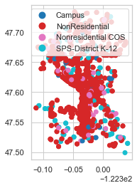

```python
gdf['geometry'].centroid
gdf.plot(column = "BuildingType",legend=True)
```

# Prediction Energy sans ENERGYSTARScore

```python
from sklearn.model_selection import train_test_split,GridSearchCV,RandomizedSearchCV,KFold,cross_val_score
from sklearn.linear_model import LinearRegression,Ridge,Lasso,ElasticNet
from sklearn.dummy import DummyRegressor
from sklearn.metrics import r2_score, mean_absolute_error,mean_squared_error,roc_auc_score,median_absolute_error
from sklearn.model_selection import learning_curve
from sklearn.feature_selection import RFE
from sklearn.ensemble import GradientBoostingRegressor,RandomForestRegressor,ExtraTreesRegressor
from sklearn.tree import DecisionTreeRegressor
from sklearn.preprocessing import StandardScaler
from math import sqrt
import scipy.stats as stats
from sklearn.compose import ColumnTransformer
from sklearn.impute import SimpleImputer
from sklearn.pipeline import Pipeline, make_pipeline
from sklearn.preprocessing import LabelEncoder,OneHotEncoder, StandardScaler
import time
```

## Preprocessing

scaling, encoding

### Log transform

```python
# apply log(x+1) element-wise to a subset of columns
df_log = df.select_dtypes(include=np.number).applymap(lambda x: np.log(x+1))

# rename columns
df_log.columns = 'log_' + df_log.columns
```

```python
df_log_cat = pd.concat((df[['LargestPropertyUseType', 'SecondLargestPropertyUseType',
                       'ThirdLargestPropertyUseType']], df_log),  axis=1)
```

### LabelEncoder

```python
occurring_cat = [cat for cat in df_log_cat.LargestPropertyUseType.value_counts().sort_values(ascending = False).head(40).index]
```

```python
for cat in occurring_cat:
    df_log_cat[cat] = np.where((df_log_cat['LargestPropertyUseType'] == cat)|
                           (df_log_cat['SecondLargestPropertyUseType'] == cat)|
                           (df_log_cat['ThirdLargestPropertyUseType'] == cat), 1, 0)
```

```python
df_log_cat
```

|  | LargestPropertyUseType | SecondLargestPropertyUseType | ThirdLargestPropertyUseType | log_Latitude | log_Longitude | log_NumberofFloors | log_PropertyGFATotal | log_PropertyGFAParking | log_PropertyGFABuilding(s) | log_ENERGYSTARScore | log_SiteEUI(kBtu/sf) | log_SourceEUI(kBtu/sf) | log_SiteEnergyUse(kBtu) | log_TotalGHGEmissions | log_pourcentage_LargestPropertyUseTypeGFA | log_pourcentage_SecondLargestPropertyUseTypeGFA | log_pourcentage_ThirdLargestPropertyUseTypeGFA | log_Build_Age | log_surface_nb_building | log_pourcentage_Electricity | log_pourcentage_NaturalGas | log_pourcentage_SteamUse | Small- and Mid-Sized Office | Warehouse | K-12 School | Other | Retail Store | Hotel | Worship Facility | … |
| --- | --- | --- | --- | --- | --- | --- | --- | --- | --- | --- | --- | --- | --- | --- | --- | --- | --- | --- | --- | --- | --- | --- | --- | --- | --- | --- | --- | --- | --- | --- |
| 0 | Hotel | NaN | NaN | 3.883874 | NaN | 2.564949 | 11.390023 | 0.000000 | 11.390023 | 4.189655 | 4.380776 | 5.161925 | 15.758764 | 5.523179 | 4.615121 | 0.000000 | 0.000000 | 4.488636 | 11.390023 | 3.985273 | 2.956472 | 3.400530 | 0 | 0 | 0 | 0 | 0 | 1 | 0 | … |
| 1 | Hotel | Parking | Restaurant | 3.883893 | NaN | 2.484907 | 11.547974 | 9.620129 | 11.390792 | 3.951244 | 4.558079 | 5.259057 | 15.938279 | 5.577879 | 4.406597 | 2.744061 | 1.697449 | 2.995732 | 11.547974 | 3.865979 | 3.993603 | 0.000000 | 0 | 0 | 0 | 0 | 0 | 1 | 0 | … |
| 2 | Hotel | Parking | Swimming Pool | 3.883898 | NaN | 3.737670 | 13.776760 | 0.000000 | 13.776760 | 2.944439 | 4.580877 | 5.495938 | 18.107758 | 7.631664 | 4.378520 | 2.433613 | 0.000000 | 3.850148 | 13.776760 | 4.234831 | 1.803359 | 3.327910 | 0 | 0 | 0 | 0 | 0 | 1 | 0 | … |
| 3 | Hotel | NaN | NaN | 3.883916 | NaN | 2.397895 | 11.023878 | 0.000000 | 11.023878 | 0.693147 | 6.134265 | 6.457241 | 17.155872 | 7.569071 | 4.615121 | 0.000000 | 0.000000 | 4.499810 | 11.023878 | 2.380472 | 2.090629 | 4.432007 | 0 | 0 | 0 | 0 | 0 | 1 | 0 | … |
| 4 | Police Station | NaN | NaN | 3.883962 | NaN | 1.098612 | 11.485441 | 10.524037 | 11.003615 | NaN | 4.917789 | 5.750984 | 16.304740 | 5.722343 | 4.525152 | 0.000000 | 0.000000 | 2.833213 | 11.485441 | 4.116269 | 3.705491 | 0.000000 | 0 | 0 | 0 | 0 | 0 | 0 | 0 | … |
| ... | ... | ... | ... | ... | ... | ... | ... | ... | ... | ... | ... | ... | ... | ... | ... | ... | ... | ... | ... | ... | ... | ... | ... | ... | ... | ... | ... | ... | ... | … |
| 2669 | Small- and Mid-Sized Office | NaN | NaN | 3.882949 | NaN | 0.693147 | 9.416948 | 0.000000 | 9.416948 | 3.850148 | 4.249923 | 5.091908 | 13.652694 | 3.088311 | 4.615121 | 0.000000 | 0.000000 | 3.295837 | 9.416948 | 4.138361 | 3.671225 | 0.000000 | 1 | 0 | 0 | 0 | 0 | 0 | 0 | … |
| 2670 | Other - Recreation | NaN | NaN | 3.883546 | NaN | 0.693147 | 9.680406 | 0.000000 | 9.680406 | NaN | 4.100989 | 4.746670 | 13.764509 | 3.501646 | 4.615121 | 0.000000 | 0.000000 | 2.564949 | 9.680406 | 3.754901 | 4.082103 | 0.000000 | 0 | 0 | 0 | 0 | 0 | 0 | 0 | … |
| 2671 | Other - Recreation | Fitness Center/Health Club/Gym | Swimming Pool | 3.884373 | NaN | 0.693147 | 9.484785 | 0.000000 | 9.484785 | NaN | 6.084955 | 6.614457 | 15.567472 | 5.414054 | 4.071247 | 3.769768 | 0.000000 | 3.761200 | 9.484785 | 3.468233 | 4.247352 | 0.000000 | 0 | 0 | 0 | 0 | 0 | 0 | 0 | … |
| 2672 | Other - Recreation | Fitness Center/Health Club/Gym | Pre-school/Daycare | 3.882148 | NaN | 0.693147 | 9.554072 | 0.000000 | 9.554072 | NaN | 3.951244 | 4.666265 | 13.486273 | 3.140265 | 3.867235 | 3.852273 | 1.488400 | 3.332205 | 9.554072 | 3.901771 | 3.961004 | 0.000000 | 0 | 0 | 0 | 0 | 0 | 0 | 0 | … |
| 2673 | Other - Recreation | Fitness Center/Health Club/Gym | Pre-school/Daycare | 3.882376 | NaN | 0.693147 | 9.812413 | 0.000000 | 9.812413 | NaN | 4.160444 | 4.760463 | 13.957789 | 3.744078 | 3.835142 | 3.802654 | 1.955860 | 4.369448 | 9.812413 | 3.651178 | 4.150725 | 0.000000 | 0 | 0 | 0 | 0 | 0 | 0 | 0 | … |

2674 rows × 62 columns

### Encodage GFA

```python
# colonne pour la surface GFA log_pourcentage_LargestPropertyUseTypeGFA
gfa_col = 'log_pourcentage_LargestPropertyUseTypeGFA'

# colonne pour le type de propriété
property_col = 'LargestPropertyUseType'

# liste des colonnes features
features_cols = ['Small- and Mid-Sized Office', 'Warehouse',
                 'K-12 School', 'Other', 'Retail Store', 'Hotel', 'Worship Facility',
                 'Distribution Center', 'Medical Office', 'Supermarket / Grocery Store',
                 'Self-Storage Facility', 'Other - Recreation', 'Parking',
                 'Other - Entertainment/Public Assembly', 'University', 'Restaurant',
                 'Refrigerated Warehouse', 'Social/Meeting Hall', 'Laboratory',
                 'Manufacturing/Industrial Plant', 'Automobile Dealership',
                 'Repair Services (Vehicle, Shoe, Locksmith, etc)', 'Museum',
                 'Hospital (General Medical & Surgical)', 'Library', 'Other - Services',
                 'Bank Branch', 'Urgent Care/Clinic/Other Outpatient', 'Other - Mall',
                 'Other - Education', 'Fitness Center/Health Club/Gym',
                 'Financial Office', 'Other/Specialty Hospital', 'Strip Mall',
                 'Performing Arts', 'Data Center', 'Pre-school/Daycare',
                 'Adult Education', 'Other - Restaurant/Bar', 'Prison/Incarceration']

# Boucle pour chaque feature
for feature in features_cols:
    # Selection des lignes ou la feature de type de propriété est égale à la feature en cours de traitement
    mask = df_log_cat[property_col] == feature
    # Assignation de la valeur de la colonne gfa_col à la colonne feature en cours de traitement
    df_log_cat.loc[mask, feature] = df_log_cat.loc[mask, gfa_col]
```

```python
# colonne pour la surface GFA log_pourcentage_SecondLargestPropertyUseTypeGFA
gfa_col = 'log_pourcentage_SecondLargestPropertyUseTypeGFA'

# colonne pour le type de propriété
property_col = 'SecondLargestPropertyUseType'

# liste des colonnes features
features_cols = ['Small- and Mid-Sized Office', 'Warehouse',
                 'K-12 School', 'Other', 'Retail Store', 'Hotel', 'Worship Facility',
                 'Distribution Center', 'Medical Office', 'Supermarket / Grocery Store',
                 'Self-Storage Facility', 'Other - Recreation', 'Parking',
                 'Other - Entertainment/Public Assembly', 'University', 'Restaurant',
                 'Refrigerated Warehouse', 'Social/Meeting Hall', 'Laboratory',
                 'Manufacturing/Industrial Plant', 'Automobile Dealership',
                 'Repair Services (Vehicle, Shoe, Locksmith, etc)', 'Museum',
                 'Hospital (General Medical & Surgical)', 'Library', 'Other - Services',
                 'Bank Branch', 'Urgent Care/Clinic/Other Outpatient', 'Other - Mall',
                 'Other - Education', 'Fitness Center/Health Club/Gym',
                 'Financial Office', 'Other/Specialty Hospital', 'Strip Mall',
                 'Performing Arts', 'Data Center', 'Pre-school/Daycare',
                 'Adult Education', 'Other - Restaurant/Bar', 'Prison/Incarceration']

# Boucle pour chaque feature
for feature in features_cols:
    # Selection des lignes ou la feature de type de propriété est égale à la feature en cours de traitement
    mask = df_log_cat[property_col] == feature
    # Assignation de la valeur de la colonne gfa_col à la colonne feature en cours de traitement
    df_log_cat.loc[mask, feature] = df_log_cat.loc[mask, gfa_col]
```

```python
# colonne pour la surface GFA log_pourcentage_ThirdLargestPropertyUseTypeGFA
gfa_col ='log_pourcentage_ThirdLargestPropertyUseTypeGFA'

# colonne pour le type de propriété
property_col ='ThirdLargestPropertyUseType'

# liste des colonnes features
features_cols = ['Small- and Mid-Sized Office', 'Warehouse',
                 'K-12 School', 'Other', 'Retail Store', 'Hotel', 'Worship Facility',
                 'Distribution Center', 'Medical Office', 'Supermarket / Grocery Store',
                 'Self-Storage Facility', 'Other - Recreation', 'Parking',
                 'Other - Entertainment/Public Assembly', 'University', 'Restaurant',
                 'Refrigerated Warehouse', 'Social/Meeting Hall', 'Laboratory',
                 'Manufacturing/Industrial Plant', 'Automobile Dealership',
                 'Repair Services (Vehicle, Shoe, Locksmith, etc)', 'Museum',
                 'Hospital (General Medical & Surgical)', 'Library', 'Other - Services',
                 'Bank Branch', 'Urgent Care/Clinic/Other Outpatient', 'Other - Mall',
                 'Other - Education', 'Fitness Center/Health Club/Gym',
                 'Financial Office', 'Other/Specialty Hospital', 'Strip Mall',
                 'Performing Arts', 'Data Center', 'Pre-school/Daycare',
                 'Adult Education', 'Other - Restaurant/Bar', 'Prison/Incarceration']

# Boucle pour chaque feature
for feature in features_cols:
    # Selection des lignes ou la feature de type de propriété est égale à la feature en cours de traitement
    mask = df_log_cat[property_col] == feature
    # Assignation de la valeur de la colonne gfa_col à la colonne feature en cours de traitement
    df_log_cat.loc[mask, feature] = df_log_cat.loc[mask, gfa_col]
```

```python
df_log_cat.drop(['LargestPropertyUseType', 'SecondLargestPropertyUseType',
                 'ThirdLargestPropertyUseType', 'log_pourcentage_LargestPropertyUseTypeGFA',
                 'log_pourcentage_SecondLargestPropertyUseTypeGFA',
                 'log_pourcentage_ThirdLargestPropertyUseTypeGFA',
                 'log_Latitude','log_Longitude','log_ENERGYSTARScore'],axis=1, inplace=True)
```

```python
df_log_cat.isna().sum()
```

```
log_NumberofFloors                                 0
log_PropertyGFATotal                               0
log_PropertyGFAParking                             0
log_PropertyGFABuilding(s)                         0
log_SiteEUI(kBtu/sf)                               0
log_SourceEUI(kBtu/sf)                             0
log_SiteEnergyUse(kBtu)                            0
log_TotalGHGEmissions                              0
log_Build_Age                                      0
log_surface_nb_building                            0
log_pourcentage_Electricity                        0
log_pourcentage_NaturalGas                         0
log_pourcentage_SteamUse                           0
Small- and Mid-Sized Office                        0
Warehouse                                          0
K-12 School                                        0
Other                                              0
Retail Store                                       0
Hotel                                              0
Worship Facility                                   0
Distribution Center                                0
Medical Office                                     0
Supermarket / Grocery Store                        0
Self-Storage Facility                              0
Other - Recreation                                 0
Parking                                            0
Other - Entertainment/Public Assembly              0
University                                         0
Restaurant                                         0
Refrigerated Warehouse                             0
Social/Meeting Hall                                0
Laboratory                                         0
Manufacturing/Industrial Plant                     0
Automobile Dealership                              0
Museum                                             0
Repair Services (Vehicle, Shoe, Locksmith, etc)    0
Hospital (General Medical & Surgical)              0
Urgent Care/Clinic/Other Outpatient                0
Bank Branch                                        0
Library                                            0
Other - Services                                   0
Fitness Center/Health Club/Gym                     0
Other - Mall                                       0
Other - Education                                  0
Financial Office                                   0
Strip Mall                                         0
Other/Specialty Hospital                           0
Data Center                                        0
Performing Arts                                    0
Pre-school/Daycare                                 0
Adult Education                                    0
Other - Restaurant/Bar                             0
Prison/Incarceration                               0
dtype: int64
```

```python
df_log_ = df_log_cat.copy()
```

```python
# Sélection des variables X et y
X=df_log_.drop(['log_SiteEnergyUse(kBtu)','log_TotalGHGEmissions'],axis=1)
y= df_log_['log_SiteEnergyUse(kBtu)']
```

### Trains Test Split

```python
# splitting the data
X_train, X_test, y_train, y_test = train_test_split(X,
                                                    y,
                                                    test_size=0.2,
                                                    random_state=0)
```

```python
X_train.shape
```

```
(2139, 51)
```

```python
X_test.shape
```

```
(535, 51)
```

```python
DummyReg_mean = DummyRegressor(strategy='mean')
DummyReg_median = DummyRegressor(strategy='median')
LinearR = LinearRegression()
Lasso = Lasso()
Ridge = Ridge()
Elastic = ElasticNet()
GardienBoostingR = GradientBoostingRegressor()
RFR = RandomForestRegressor()
ExtraTR = ExtraTreesRegressor()
```

## Modelisation sans Energystarscore

La normalisation des données est généralement recommandée pour les modèles de régression linéaire (LinearRegression, Lasso, Ridge, ElasticNet)

Les modèles de régression linéaire utilisent des fonctions linéaires pour effectuer des prévisions, et la normalisation des données peut aider à éviter que certaines caractéristiques n'aient une influence excessive sur les résultats en raison de leurs grandes échelles.

```python
def evaluation(model):
    model.fit(X_train, y_train)
    y_pred = model.predict(X_test)
    N, train_scores, val_scores = learning_curve(
        model, X_train, y_train, train_sizes=np.linspace(0.1, 1.0, 10), cv=5)

    fig, axes = plt.subplots(nrows=1, ncols=2, sharex=False, sharey=False, figsize=(20,8))
    axes[0].plot(N, train_scores.mean(axis=1), '--',
             color="#110011",  label="Training score")
    axes[0].plot(N, val_scores.mean(axis=1), color="#834651",
             label="Cross-validation score")
    axes[0].set_title(f'{model}Learning Curve')
    axes[0].set_xlabel("Training Set Size")
    axes[0].set_ylabel("RMSE Score")

    axes[1].plot(y_train, y_train, c='red', lw=3)
    axes[1].scatter(y_test, y_test_pred, alpha=.6)
    axes[1].set_xlabel('Y Test Actual')
    axes[1].set_ylabel('Y Test Predicted')
    axes[1].set_title(f'{model}Predicted Y value by Actual Y value on Testing Data, Full Model')
```

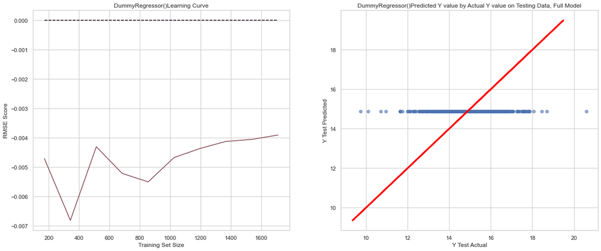

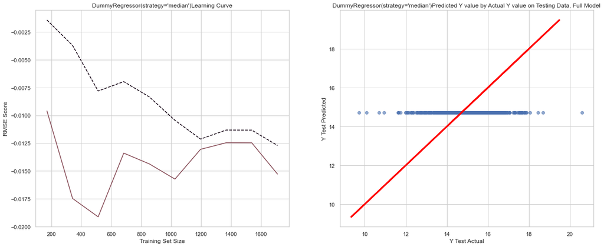

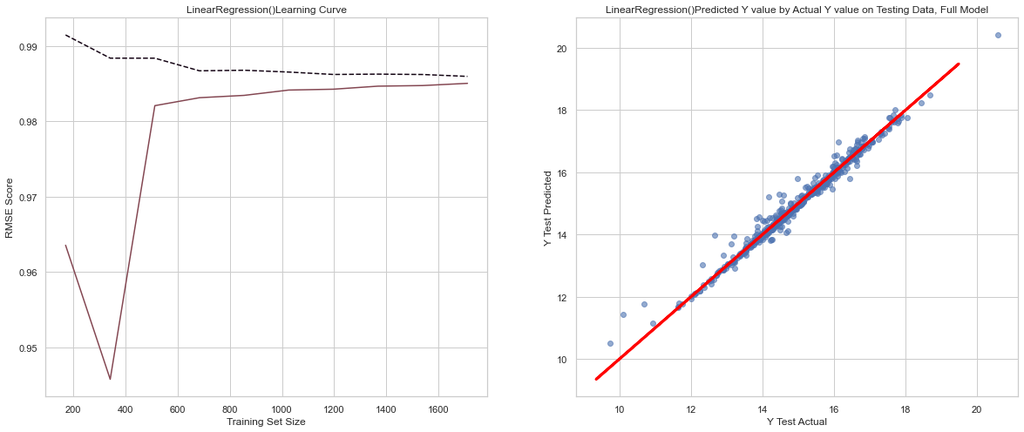

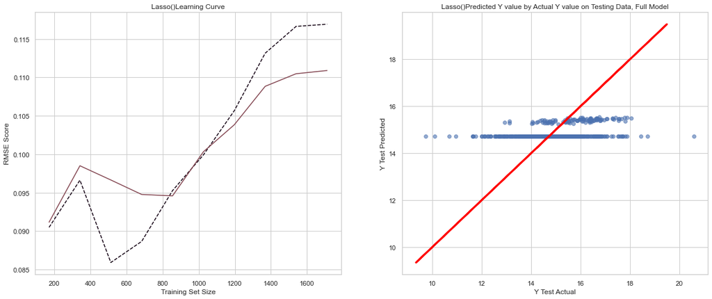

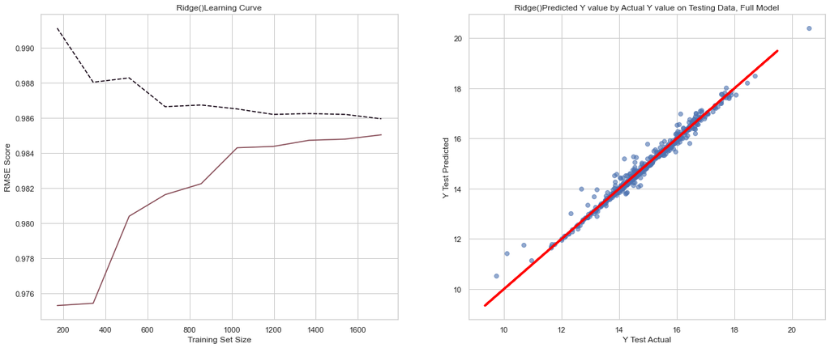

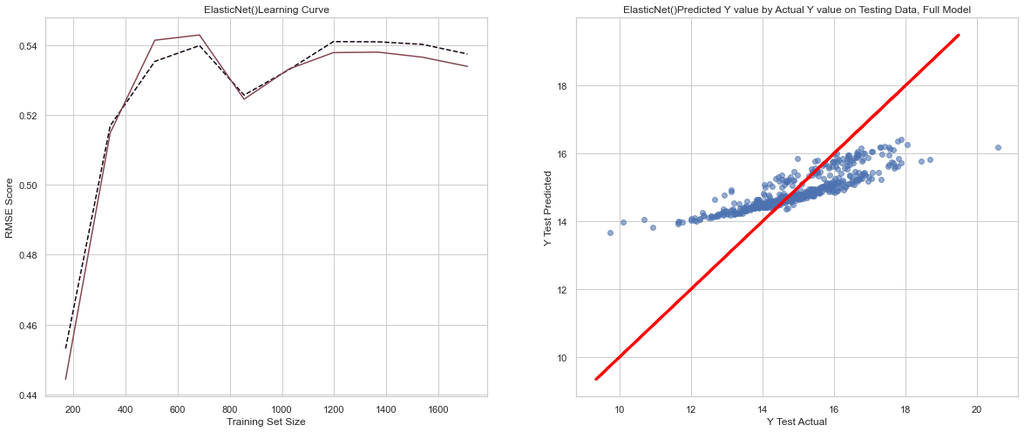

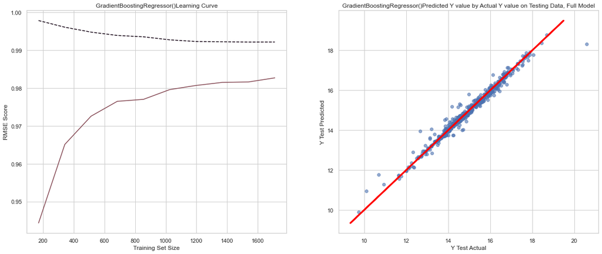

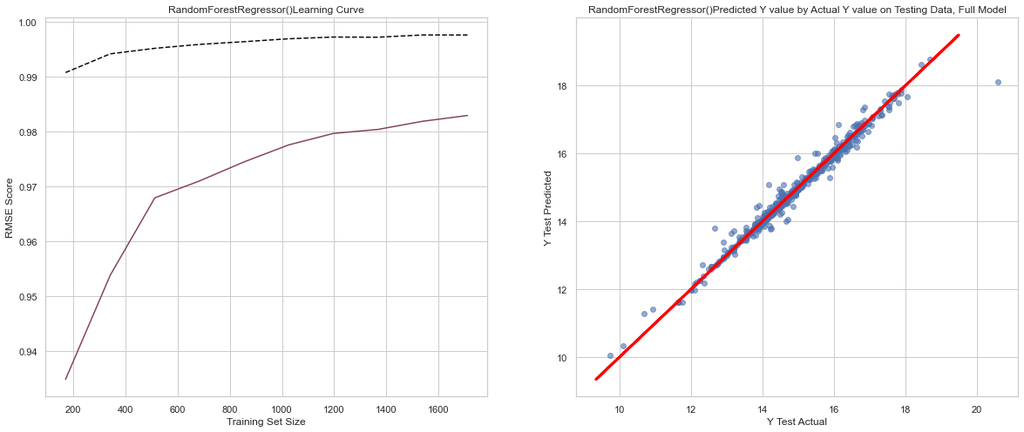

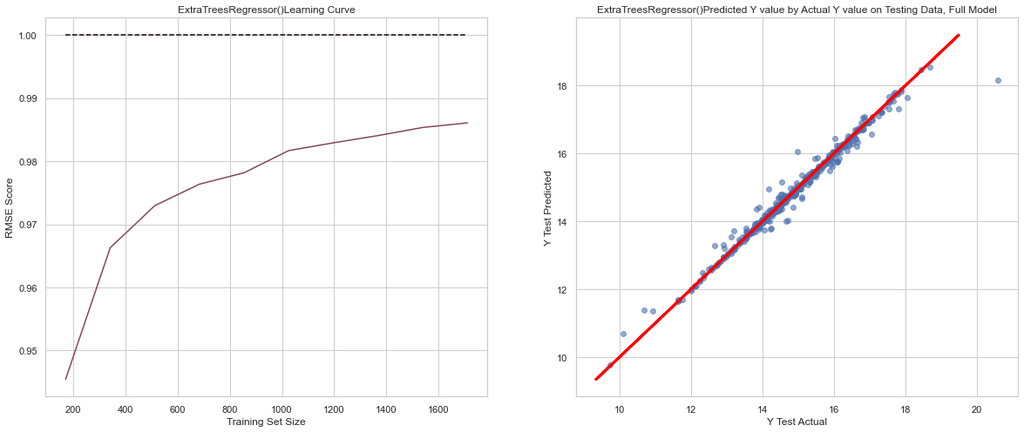

```python
# Entraîner et évaluer les modèles
models = {'dummy_regr_mean': DummyReg_mean,
          'dummy_regr_median': DummyReg_median,
          'linearr': LinearR,
          'lasso': Lasso,
          'ridge': Ridge,
          'elastic': Elastic,
          'GB': GardienBoostingR,
          'rfr': RFR,
          'ETR': ExtraTR}

results = {}
for name, model in models.items():
    # Début de la mesure du temps
    start_time = time.time()
    model.fit(X_train, y_train)
     # Fin de la mesure du temps
    end_time = time.time()
    y_train_pred = model.predict(X_train)
    y_test_pred = model.predict(X_test)
    tr_mae = median_absolute_error(y_train, y_train_pred)
    valid_mae = median_absolute_error(y_test, y_test_pred)
    train_rmse = mean_squared_error(y_train,y_train_pred)**0.5
    valid_rmse = mean_squared_error(y_test,y_test_pred)**0.5
    # Calcul du temps d'entraînement
    training_time = end_time - start_time
    results[name] = [round(tr_mae,3), round(valid_mae,3), round(train_rmse,3), round(valid_rmse,3),training_time]
    evaluation(model)
```

```python
results_df = pd.DataFrame(results).T
results_df.columns = ["Train MAE", "Validation MAE","Train RMSE", "Valid RMSE",'Temps']
results_df.sort_values(by='Validation MAE',ascending=True)
```

|  | Train MAE | Validation MAE | Train RMSE | Valid RMSE | Temps |
| --- | --- | --- | --- | --- | --- |
| ETR | 0.000 | 0.033 | 0.000 | 0.180 | 1.479043 |
| rfr | 0.018 | 0.049 | 0.060 | 0.198 | 1.598723 |
| linearr | 0.058 | 0.057 | 0.158 | 0.198 | 0.008976 |
| ridge | 0.057 | 0.057 | 0.158 | 0.198 | 0.003993 |
| GB | 0.057 | 0.075 | 0.122 | 0.215 | 0.683171 |
| elastic | 0.574 | 0.577 | 0.901 | 0.933 | 0.005987 |
| lasso | 0.800 | 0.789 | 1.246 | 1.269 | 0.003990 |
| dummy_regr_median | 0.844 | 0.819 | 1.334 | 1.356 | 0.000000 |
| dummy_regr_mean | 0.877 | 0.854 | 1.326 | 1.348 | 0.000997 |

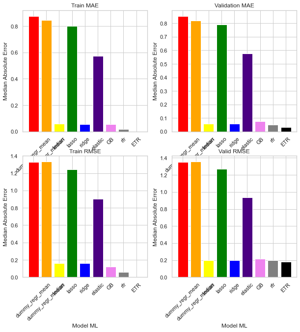

```python
# Créer une figure avec 4 sous-graphes
fig, axs = plt.subplots(2, 2, figsize=(15, 15))

colors = ['red', 'orange', 'yellow', 'green', 'blue', 'indigo', 'violet', 'gray', 'black']

for i, color in enumerate(colors):
    axs[0, 0].bar(results_df.index[i], results_df['Train MAE'][i], color=color)
    axs[0, 0].set_title("Train MAE")
    axs[0, 0].set_xlabel("Model ML")
    axs[0, 0].set_ylabel("Median Absolute Error")
    axs[0, 0].set_xticklabels(results_df.index, rotation=45)

    axs[0, 1].bar(results_df.index[i], results_df['Validation MAE'][i], color=color)
    axs[0, 1].set_title("Validation MAE")
    axs[0, 1].set_xlabel("Model ML")
    axs[0, 1].set_ylabel("Median Absolute Error")
    axs[0, 1].set_xticklabels(results_df.index, rotation=45)

    axs[1, 0].bar(results_df.index[i], results_df['Train RMSE'][i], color=color)
    axs[1, 0].set_title("Train RMSE")
    axs[1, 0].set_xlabel("Model ML")
    axs[1, 0].set_ylabel("Median Absolute Error")
    axs[1, 0].set_xticklabels(results_df.index, rotation=45)

    axs[1, 1].bar(results_df.index[i], results_df['Valid RMSE'][i], color=color)
    axs[1, 1].set_title("Valid RMSE")
    axs[1, 1].set_xlabel("Model ML")
    axs[1, 1].set_ylabel("Median Absolute Error")
    axs[1, 1].set_xticklabels(results_df.index, rotation=45)
plt.show()
```

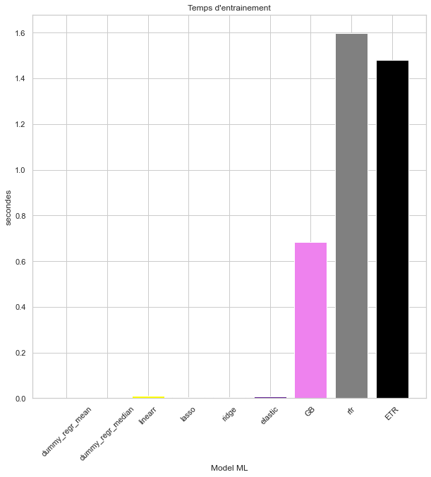

```python
plt.figure(figsize=(10, 10))
plt.bar(results_df.index, results_df['Temps'], color=colors)
plt.title("Temps d'entrainement")
plt.xlabel("Model ML")
plt.ylabel("secondes")
plt.xticks(rotation=45)
plt.show()
```

## Optimisation sans Energystarscore

### Ridge regression

```python
folds  = KFold(n_splits=10,shuffle=True,random_state=42)

hyper_param = {'alpha':np.arange(0.0001,1e6,1000)}

model_cv = GridSearchCV(estimator=Ridge,
                        param_grid=hyper_param,
                        scoring='r2',
                        cv=folds,
                        verbose=1,
                        return_train_score=True)

model_cv.fit(X_train,y_train)
```

```
Fitting 10 folds for each of 1000 candidates, totalling 10000 fits
```

```
GridSearchCV(cv=KFold(n_splits=10, random_state=42, shuffle=True),
             estimator=Ridge(),
             param_grid={'alpha': array([1.00000000e-04, 1.00000010e+03, 2.00000010e+03, 3.00000010e+03,
       4.00000010e+03, 5.00000010e+03, 6.00000010e+03, 7.00000010e+03,
       8.00000010e+03, 9.00000010e+03, 1.00000001e+04, 1.10000001e+04,
       1.20000001e+04, 1.30000001e+04, 1.40000001e+04, 1.50000001e+04,
       1...
       9.80000000e+05, 9.81000000e+05, 9.82000000e+05, 9.83000000e+05,
       9.84000000e+05, 9.85000000e+05, 9.86000000e+05, 9.87000000e+05,
       9.88000000e+05, 9.89000000e+05, 9.90000000e+05, 9.91000000e+05,
       9.92000000e+05, 9.93000000e+05, 9.94000000e+05, 9.95000000e+05,
       9.96000000e+05, 9.97000000e+05, 9.98000000e+05, 9.99000000e+05])},
             return_train_score=True, scoring='r2', verbose=1)
```

```python
cv_result_r = pd.DataFrame(model_cv.cv_results_)
cv_result_r['param_alpha'] = cv_result_r['param_alpha'].astype('float32')
cv_result_r.head()
```

|  | mean_fit_time | std_fit_time | mean_score_time | std_score_time | param_alpha | params | split0_test_score | split1_test_score | split2_test_score | split3_test_score | split4_test_score | split5_test_score | split6_test_score | split7_test_score | split8_test_score | split9_test_score | mean_test_score | std_test_score | rank_test_score | split0_train_score | split1_train_score | split2_train_score | split3_train_score | split4_train_score | split5_train_score | split6_train_score | split7_train_score | split8_train_score | split9_train_score | … |
| --- | --- | --- | --- | --- | --- | --- | --- | --- | --- | --- | --- | --- | --- | --- | --- | --- | --- | --- | --- | --- | --- | --- | --- | --- | --- | --- | --- | --- | --- | --- |
| 0 | 0.005786 | 0.001888 | 0.002487 | 0.001014 | 0.000100 | {'alpha': 0.0001} | 0.982685 | 0.982256 | 0.986240 | 0.982033 | 0.987088 | 0.988042 | 0.988807 | 0.984810 | 0.982494 | 0.983789 | 0.984824 | 0.002425 | 1 | 0.986130 | 0.986127 | 0.985795 | 0.986234 | 0.985686 | 0.985544 | 0.985470 | 0.985888 | 0.986201 | 0.986021 | … |
| 1 | 0.004991 | 0.001485 | 0.003486 | 0.001110 | 1000.000122 | {'alpha': 1000.0001} | 0.931963 | 0.932529 | 0.927300 | 0.922130 | 0.929121 | 0.930133 | 0.948373 | 0.931258 | 0.931919 | 0.924662 | 0.930939 | 0.006654 | 2 | 0.933632 | 0.931535 | 0.933775 | 0.933580 | 0.933820 | 0.932933 | 0.933037 | 0.932536 | 0.932694 | 0.932629 | … |
| 2 | 0.004788 | 0.000869 | 0.002794 | 0.000747 | 2000.000122 | {'alpha': 2000.0001} | 0.868984 | 0.867007 | 0.865169 | 0.855460 | 0.866213 | 0.869661 | 0.900487 | 0.866167 | 0.871568 | 0.853753 | 0.868447 | 0.012024 | 3 | 0.872721 | 0.869163 | 0.872527 | 0.872739 | 0.872097 | 0.871280 | 0.870210 | 0.870884 | 0.870838 | 0.871212 | … |
| 3 | 0.004786 | 0.001163 | 0.003091 | 0.000699 | 3000.000000 | {'alpha': 3000.0001} | 0.810158 | 0.806730 | 0.807493 | 0.795532 | 0.805651 | 0.813732 | 0.851309 | 0.806166 | 0.815982 | 0.789264 | 0.810202 | 0.015639 | 4 | 0.815679 | 0.811190 | 0.815221 | 0.815816 | 0.814549 | 0.813453 | 0.811447 | 0.813335 | 0.813016 | 0.814072 | … |
| 4 | 0.005087 | 0.001215 | 0.002891 | 0.000939 | 4000.000000 | {'alpha': 4000.0001} | 0.758089 | 0.753945 | 0.756633 | 0.743575 | 0.751494 | 0.764124 | 0.805718 | 0.753507 | 0.767051 | 0.733263 | 0.758740 | 0.018143 | 5 | 0.765110 | 0.760047 | 0.764450 | 0.765336 | 0.763735 | 0.762195 | 0.759471 | 0.762422 | 0.761803 | 0.763611 | … |

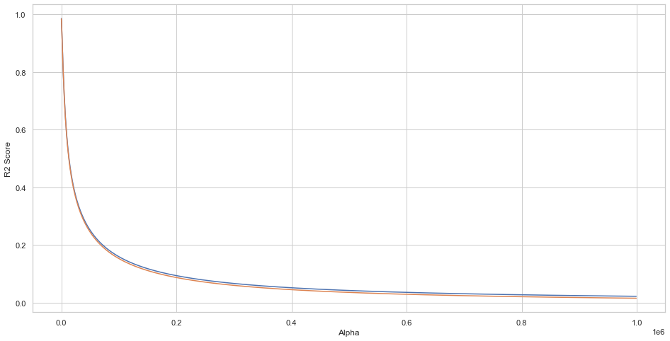

```python
plt.figure(figsize=(16,8))
plt.plot(cv_result_r['param_alpha'],cv_result_r['mean_train_score'])
plt.plot(cv_result_r['param_alpha'],cv_result_r['mean_test_score'])
plt.xlabel('Alpha')
# plt.xscale('log')
plt.ylabel('R2 Score')
plt.show()
```

```python
print(model_cv.best_params_)
```

```
{'alpha': 0.0001}
```

```python
from sklearn.linear_model import Ridge
ridge = Ridge(alpha = 0.0001)
```

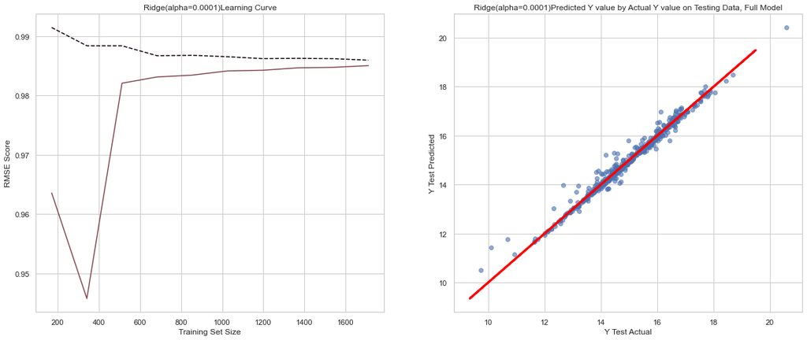

```python
# Entraîner et évaluer le model optimisé
models = {'ridge_opt': ridge}


results_opt = {}
for name, model in models.items():
    # Début de la mesure du temps
    start_time = time.time()
    model.fit(X_train, y_train)
     # Fin de la mesure du temps
    end_time = time.time()
    y_train_pred = model.predict(X_train)
    y_test_pred = model.predict(X_test)
    tr_mae = median_absolute_error(y_train, y_train_pred)
    valid_mae = median_absolute_error(y_test, y_test_pred)
    train_rmse = mean_squared_error(y_train,y_train_pred)**0.5
    valid_rmse = mean_squared_error(y_test,y_test_pred)**0.5
    # Calcul du temps d'entraînement
    training_time = end_time - start_time
    results_opt[name] = [round(tr_mae,3), round(valid_mae,3), round(train_rmse,3), round(valid_rmse,3),training_time]
    evaluation(model)
```

```python
model_parameter = list(ridge.coef_)
model_parameter.insert(0,ridge.intercept_)
cols = X_train.columns
cols.insert(0,'constant')
ridge_coef = pd.DataFrame(list(zip(cols,model_parameter)))
ridge_coef.columns = ['Features','Coef']
```

```python
ridge_coef.sort_values(by='Coef',ascending=False).head(10)
```

|  | Features | Coef |
| --- | --- | --- |
| 5 | log_SourceEUI(kBtu/sf) | 1.012494 |
| 4 | log_SiteEUI(kBtu/sf) | 0.514520 |
| 2 | log_PropertyGFAParking | 0.456836 |
| 0 | log_NumberofFloors | 0.088313 |
| 48 | Adult Education | 0.037137 |
| 36 | Bank Branch | 0.036553 |
| 49 | Other - Restaurant/Bar | 0.034541 |
| 26 | Restaurant | 0.033697 |
| 44 | Other/Specialty Hospital | 0.033203 |
| 14 | Other | 0.029685 |

```python
results_opt_df = pd.DataFrame(results_opt).T
results_opt_df.columns = ["Train MAE", "Validation MAE","Train RMSE", "Valid RMSE",'Temps']
df_resultat= pd.concat([results_df, results_opt_df],  axis=0)
df_resultat.sort_values(by='Validation MAE',ascending=True)
```

|  | Train MAE | Validation MAE | Train RMSE | Valid RMSE | Temps |
| --- | --- | --- | --- | --- | --- |
| ETR | 0.000 | 0.033 | 0.000 | 0.180 | 1.479043 |
| rfr | 0.018 | 0.049 | 0.060 | 0.198 | 1.598723 |
| linearr | 0.058 | 0.057 | 0.158 | 0.198 | 0.008976 |
| ridge | 0.057 | 0.057 | 0.158 | 0.198 | 0.003993 |
| ridge_opt | 0.058 | 0.057 | 0.158 | 0.198 | 0.005981 |
| GB | 0.057 | 0.075 | 0.122 | 0.215 | 0.683171 |
| elastic | 0.574 | 0.577 | 0.901 | 0.933 | 0.005987 |
| lasso | 0.800 | 0.789 | 1.246 | 1.269 | 0.003990 |
| dummy_regr_median | 0.844 | 0.819 | 1.334 | 1.356 | 0.000000 |
| dummy_regr_mean | 0.877 | 0.854 | 1.326 | 1.348 | 0.000997 |

# Model vs ENERGYSTARScore

ENERGY STAR provides a comprehensive overview of a building's energy performance, taking into account physical assets, operations, and the behavior of building occupants. It is expressed on a scale of 1 to 100

```python
#Filtrage des données ayant un Energy Star Score renseigné
df = df[df['ENERGYSTARScore'].isnull()==False]
df_log_cat = df_log_cat[df_log_cat.index.isin(list(df.index))]
```

```python
df_log_energyscore = pd.concat([df_log_cat, df[['ENERGYSTARScore']]], axis=1)
```

```python
# Sélection des variables X et y
X = df_log_energyscore.drop(
    ['log_SiteEnergyUse(kBtu)', 'log_TotalGHGEmissions'], axis=1)
y = df_log_energyscore['log_SiteEnergyUse(kBtu)']
```

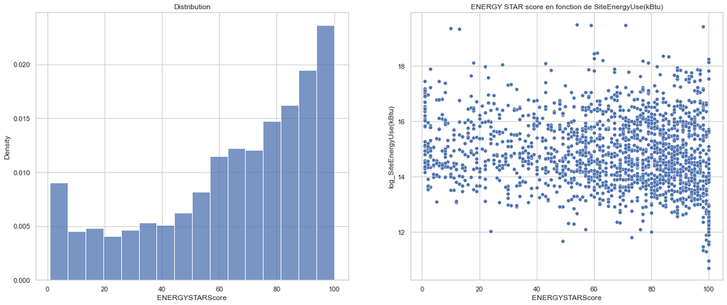

```python
fig, axes = plt.subplots(nrows=1, ncols=2, sharex=False, sharey=False, figsize=(20,8))
sns.histplot(data=X, x='ENERGYSTARScore', stat="density", ax=axes[0])
axes[0].set_title("Distribution")
sns.scatterplot(data=pd.concat([X,y], axis=1), y='log_SiteEnergyUse(kBtu)', x='ENERGYSTARScore', ax=axes[1])
axes[1].set_title("ENERGY STAR score en fonction de SiteEnergyUse(kBtu)")
plt.show()
```

```python
# splitting the data
X_train, X_test, y_train, y_test = train_test_split(X,
                                                    y,
                                                    test_size=0.2,
                                                    random_state=0)
```

```python
def evaluation_energyscore(model):
    model.fit(X_train, y_train)
    y_pred = model.predict(X_test)
    N, train_scores, val_scores = learning_curve(
        model, X_train, y_train, train_sizes=np.linspace(0.1, 1.0, 10), cv=5)

    fig, axes = plt.subplots(nrows=1, ncols=2, sharex=False, sharey=False, figsize=(20,8))
    axes[0].plot(N, train_scores.mean(axis=1), '--',
             color="#110011",  label="Training score")
    axes[0].plot(N, val_scores.mean(axis=1), color="#834651",
             label="Cross-validation score")
    axes[0].set_title(f'{model}Learning Curve')
    axes[0].set_xlabel("Training Set Size")
    axes[0].set_ylabel("RMSE Score")

    axes[1].plot(y_train, y_train, c='red', lw=3)
    axes[1].scatter(y_test, y_pred, alpha=.6)
    axes[1].set_xlabel('Y Test Actual')
    axes[1].set_ylabel('Y Test Predicted')
    axes[1].set_title(f'{model}Predicted Y value by Actual Y value on Testing Data, Full Model')
```

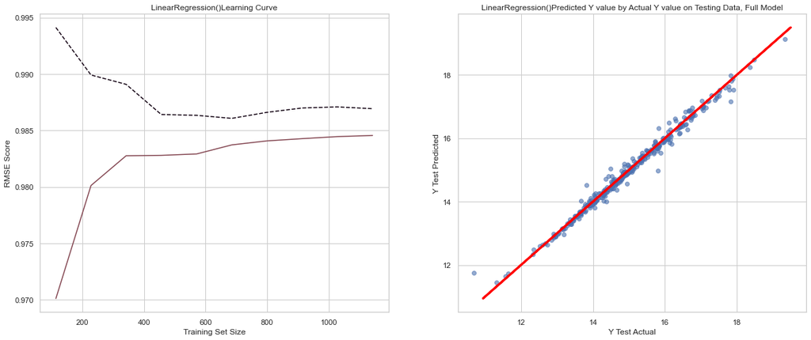

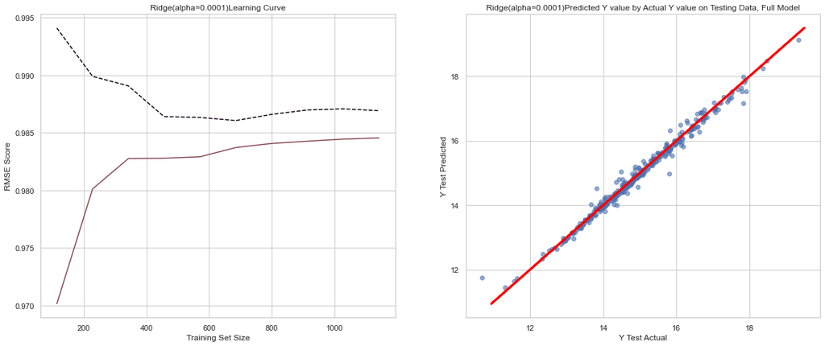

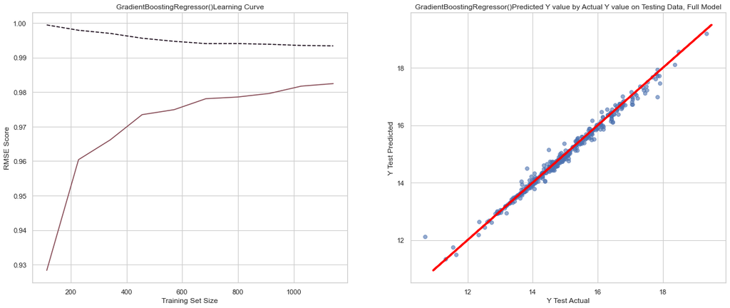

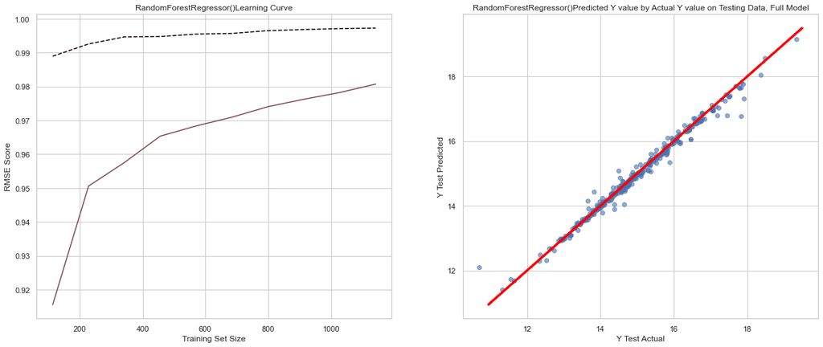

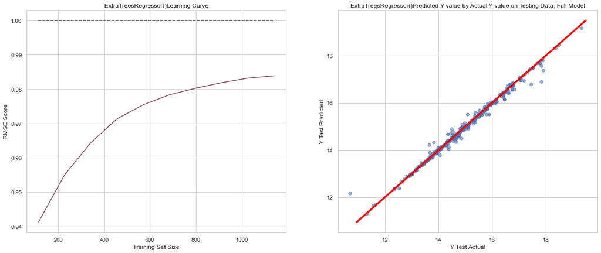

```python
# Entraîner et évaluer les modèles
models = {'linearr': LinearR,
          'ridge': ridge,
          'GB': GardienBoostingR,
          'rfr': RFR,
          'ETR': ExtraTR}


results_energyscore = {}
for name, model in models.items():
    # Début de la mesure du temps
    start_time = time.time()
    model.fit(X_train, y_train)
     # Fin de la mesure du temps
    end_time = time.time()
    y_train_pred = model.predict(X_train)
    y_test_pred = model.predict(X_test)
    tr_mae = median_absolute_error(y_train, y_train_pred)
    valid_mae = median_absolute_error(y_test, y_test_pred)
    train_rmse = mean_squared_error(y_train,y_train_pred)**0.5
    valid_rmse = mean_squared_error(y_test,y_test_pred)**0.5
    # Calcul du temps d'entraînement
    training_time = end_time - start_time
    results_energyscore[name] = [round(tr_mae,3), round(valid_mae,3), round(train_rmse,3), round(valid_rmse,3),training_time]
    evaluation_energyscore(model)
```

```python
# Stocker les résultats dans un dataframe
results_energyscore_df = pd.DataFrame(results_energyscore).T
results_energyscore_df.columns = ["Train MAE", "Validation MAE","Train RMSE", "Valid RMSE",'Temps']
```

```python
print("Sans energyscore")
df_resultat.sort_values(by='Validation MAE',ascending=True)
```

```
Sans energyscore
```

|  | Train MAE | Validation MAE | Train RMSE | Valid RMSE | Temps |
| --- | --- | --- | --- | --- | --- |
| ETR | 0.000 | 0.033 | 0.000 | 0.180 | 1.479043 |
| rfr | 0.018 | 0.049 | 0.060 | 0.198 | 1.598723 |
| linearr | 0.058 | 0.057 | 0.158 | 0.198 | 0.008976 |
| ridge | 0.057 | 0.057 | 0.158 | 0.198 | 0.003993 |
| ridge_opt | 0.058 | 0.057 | 0.158 | 0.198 | 0.005981 |
| GB | 0.057 | 0.075 | 0.122 | 0.215 | 0.683171 |
| elastic | 0.574 | 0.577 | 0.901 | 0.933 | 0.005987 |
| lasso | 0.800 | 0.789 | 1.246 | 1.269 | 0.003990 |
| dummy_regr_median | 0.844 | 0.819 | 1.334 | 1.356 | 0.000000 |
| dummy_regr_mean | 0.877 | 0.854 | 1.326 | 1.348 | 0.000997 |

```python
print("Avec energyscore")
results_energyscore_df.sort_values(by='Validation MAE',ascending=True)
```

```
Avec energyscore
```

|  | Train MAE | Validation MAE | Train RMSE | Valid RMSE | Temps |
| --- | --- | --- | --- | --- | --- |
| ETR | 0.000 | 0.029 | 0.000 | 0.141 | 1.432170 |
| rfr | 0.021 | 0.053 | 0.061 | 0.161 | 1.111029 |
| linearr | 0.058 | 0.063 | 0.145 | 0.148 | 0.012965 |
| ridge | 0.058 | 0.063 | 0.145 | 0.148 | 0.003990 |
| GB | 0.052 | 0.068 | 0.105 | 0.162 | 0.589422 |

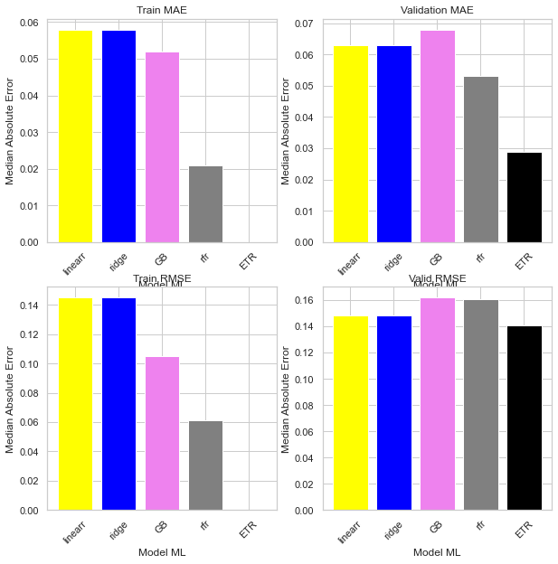

```python
# Créer une figure avec 4 sous-graphes
fig, axs = plt.subplots(2, 2, figsize=(15, 15))

colors = ['yellow', 'blue', 'violet', 'gray', 'black']

for i, color in enumerate(colors):
    axs[0, 0].bar(results_energyscore_df.index[i], results_energyscore_df['Train MAE'][i], color=color)
    axs[0, 0].set_title("Train MAE")
    axs[0, 0].set_xlabel("Model ML")
    axs[0, 0].set_ylabel("Median Absolute Error")
    axs[0, 0].set_xticklabels(results_energyscore_df.index, rotation=45)

    axs[0, 1].bar(results_energyscore_df.index[i], results_energyscore_df['Validation MAE'][i], color=color)
    axs[0, 1].set_title("Validation MAE")
    axs[0, 1].set_xlabel("Model ML")
    axs[0, 1].set_ylabel("Median Absolute Error")
    axs[0, 1].set_xticklabels(results_energyscore_df.index, rotation=45)

    axs[1, 0].bar(results_energyscore_df.index[i], results_energyscore_df['Train RMSE'][i], color=color)
    axs[1, 0].set_title("Train RMSE")
    axs[1, 0].set_xlabel("Model ML")
    axs[1, 0].set_ylabel("Median Absolute Error")
    axs[1, 0].set_xticklabels(results_energyscore_df.index, rotation=45)

    axs[1, 1].bar(results_energyscore_df.index[i], results_energyscore_df['Valid RMSE'][i], color=color)
    axs[1, 1].set_title("Valid RMSE")
    axs[1, 1].set_xlabel("Model ML")
    axs[1, 1].set_ylabel("Median Absolute Error")
    axs[1, 1].set_xticklabels(results_energyscore_df.index, rotation=45)
plt.show()
```